# POTD 02 - Data Visualization

Simon Chen

10/4/2021

## Task 1

Access the help on the data set `state.x77` and briefly describe the data. Convert it to a data frame (tibble) with `as_tibble()`. For example, `dat <- as_tibble(state.x77)`. Now work with the data called dat.

```r
library(tidyverse)
# Check the state.x77 data set.
?state.x77
#state.x77: matrix with 50 rows and 8 columns giving the following statistics in the respective columns. Population: population estimate as of July 1, 1975. Income: per capita income (1974). Illiteracy: illiteracy (1970, percent of population). Life Exp: life expectancy in years (1969–71). Murder: murder and non-negligent manslaughter rate per 100,000 population (1976). HS Grad: percent high-school graduates (1970). Frost: mean number of days with minimum temperature below freezing (1931–1960) in capital or large city. Area:land area in square miles.

# Convert it to a data frame (tibble) with as_tibble().
dat <- as_tibble(state.x77)
dat
```

```
## # A tibble: 50 × 8
##    Population Income Illiteracy `Life Exp` Murder `HS Grad` Frost   Area
##         <dbl>  <dbl>      <dbl>      <dbl>  <dbl>     <dbl> <dbl>  <dbl>
##  1       3615   3624        2.1       69.0   15.1      41.3    20  50708
##  2        365   6315        1.5       69.3   11.3      66.7   152 566432
##  3       2212   4530        1.8       70.6    7.8      58.1    15 113417
##  4       2110   3378        1.9       70.7   10.1      39.9    65  51945
##  5      21198   5114        1.1       71.7   10.3      62.6    20 156361
##  6       2541   4884        0.7       72.1    6.8      63.9   166 103766
##  7       3100   5348        1.1       72.5    3.1      56     139   4862
##  8        579   4809        0.9       70.1    6.2      54.6   103   1982
##  9       8277   4815        1.3       70.7   10.7      52.6    11  54090
## 10       4931   4091        2         68.5   13.9      40.6    60  58073
## # … with 40 more rows
```

## Task 2

Make a scatterplot of murder rate (on x-axis) and life expectancy (on y-axis).

```r
# Show the variables name to check potential space error.
names(dat)
```

```
## [1] "Population" "Income"     "Illiteracy" "Life Exp"   "Murder"
## [6] "HS Grad"    "Frost"      "Area"
```

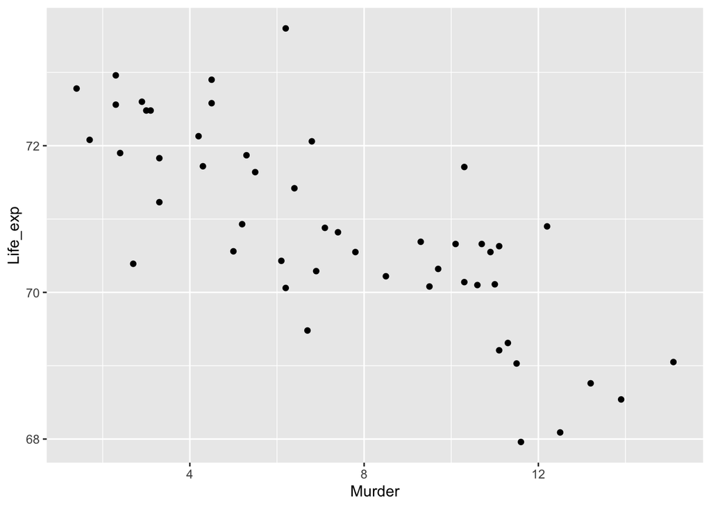

```r
# To rename variables for indexing
names(dat)[4] <- 'Life_exp'
# To plot with murder and life exp.
ggplot(data = dat) +
  geom_point(mapping = aes(x = Murder, y = Life_exp))
```

## Task 3

Access the help on `state.region` and `state.division` and `state.abb`. Briefly describe them each.

```r
?state
```

state.region: factor giving the region (Northeast, South, North Central, West) that each state belongs to.  
state.division: factor giving state divisions (New England, Middle Atlantic, South Atlantic, East South Central, West South Central, East North Central, West North Central, Mountain, and Pacific).  
state.abb: character vector of 2-letter abbreviations for the state names.

## Task 4

Building on the scatterplot you made above in (2), color the points by state region.

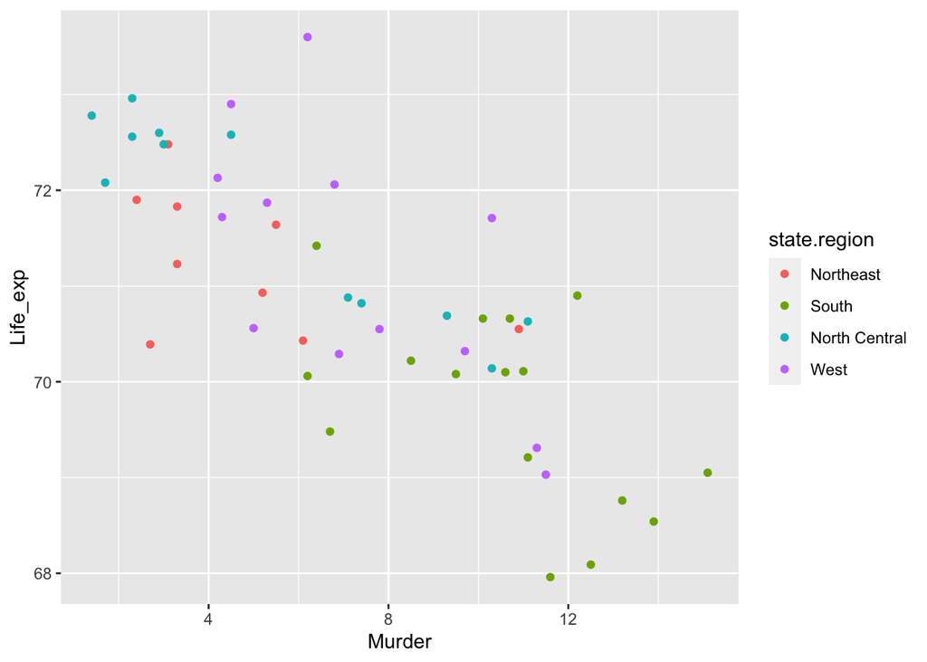

```r
ggplot(data = dat) +
  geom_point(mapping = aes(x = Murder, y = Life_exp, color = state.region))
```

## Task 5

Building on the scatterplot you made above in (2), create a faceted plot by state division.

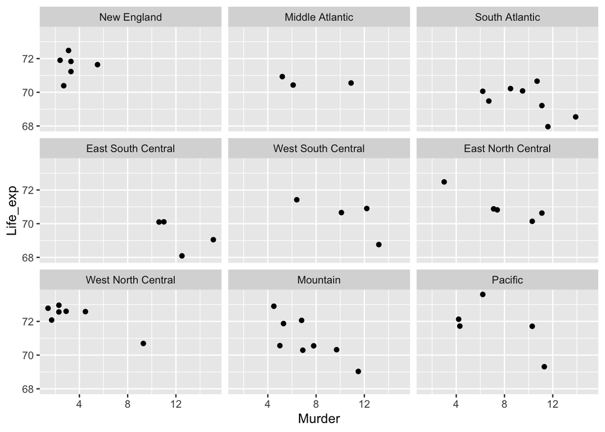

```r
ggplot(data = dat) +
  geom_point(mapping = aes(x = Murder, y = Life_exp)) +
               facet_wrap(state.division)
```

## Task 6

Building on the scatterplot you made above in (2), add a nonparametric regression (loess) curve with standard error bars.

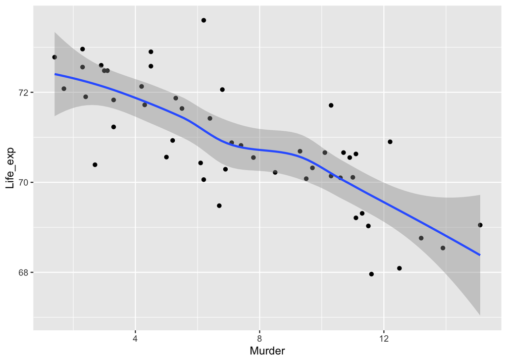

```r
ggplot(data = dat, mapping = aes(x = Murder, y = Life_exp)) +
  geom_point() +
  geom_smooth()
```